# House Selling Prices

##### 2. Less Rooms are Better for Low Quality Homes

$\beta_1$ singles out homes that are low quality (below 7). As the quality score increases, that switches to positive. A quality score of 7 ($\beta_3$) adds $3,417 to the slope, equaling -$1,797. For every additional room above ground in a quality 7 home, the predicted price goes down by $1,797. For a quality 10 home ($\beta_2$), the price increases $12,101 for every additional room.

One way to see this on the graph is the flip of 2 rooms and 14 rooms. At lower quality levels, the 14 is below 2, and it flips to 14 above 2. This flip matches the explanation of the negative base coefficient tied to increasing interaction terms.

##### 3. Living Area and Neighborhood are Equally or More Impactful

Visually, there is a very strong tie between living are and sale price, and a dramatic shift in slope from one neighborhood to another, with higher neighborhoods having higher slope.

### Model

All P-values in this model are highly significant. The standard errors are practically large, which is not ideal for exact prediction. The adjusted $R^2 = 0.8207$ meaning the model explains 82% of the variation in Sale Price.

```r
summary(mylm) %>% pander()
```

|  | Estimate | Std. Error | t value | Pr(>\|t\|) |
| --- | --- | --- | --- | --- |
| **(Intercept)** | 98759 | 3930 | 25.13 | 5.742e-116 |
| **TotRmsAbvGrd** | -5214 | 983.6 | -5.301 | 1.332e-07 |
| **TotRmsAbvGrd:GeneralQual10** | 17315 | 1003 | 17.26 | 6.95e-61 |
| **TotRmsAbvGrd:GeneralQual7** | 3417 | 376.6 | 9.072 | 3.707e-19 |
| **TotRmsAbvGrd:GeneralQual8** | 7784 | 493.4 | 15.78 | 7.259e-52 |
| **TotRmsAbvGrd:GeneralQual9** | 16003 | 754.6 | 21.21 | 3.785e-87 |
| **GrLivArea:NbhdTypeHigh** | 90.57 | 3.616 | 25.05 | 2.319e-115 |
| **GrLivArea:NbhdTypeLow** | 57.14 | 3.683 | 15.51 | 2.453e-50 |
| **GrLivArea:NbhdTypeMid** | 74.01 | 3.466 | 21.35 | 3.418e-88 |
| **GrLivArea:NbhdTypeVery Low** | 37.5 | 3.636 | 10.31 | 4.044e-24 |

Fitting linear model: SalePrice ~ TotRmsAbvGrd + TotRmsAbvGrd:GeneralQual + GrLivArea:NbhdType

| Observations | Residual Std. Error | $R^2$ | Adjusted $R^2$ |
| --- | --- | --- | --- |
| 1460 | 33635 | 0.8218 | 0.8207 |

### Validation

While this only shows one “random” seed, this model does usually predict about 80% after trying multiple random predictions. By taking a portion of the data to fit the model and a portion to predict with, we can see the model’s effectiveness on new data.

```r
set.seed(122)

num_rows <- 1000 #1460 total
keep <- sample(1:nrow(train), num_rows)

mytrain <- train[keep, ] #Use this in the lm(..., data=mytrain) it is like "rbdata"

mytest <- train[-keep, ] #Use this in the predict(..., newdata=mytest) it is like "rbdata2"

mylm <- lm(SalePrice ~ TotRmsAbvGrd + TotRmsAbvGrd:GeneralQual + GrLivArea:NbhdType, mytrain)
yhat <- predict(mylm, newdata = mytest)
ybar <- mean(mytest$SalePrice)
SSTO <- sum((mytest$SalePrice - ybar)^2)
SSE <- sum((mytest$SalePrice - yhat)^2)
r2 <- 1 - SSE / SSTO

# Trying to make a function that runs all the above code
# I would have to identify the column (eg. mytest$SalePrice)
# test_r2 <- function(model, test_data) {
#   yhat <- predict(mylm, newdata = test_data)
#   ybar <- mean(mytest)
#   SSTO <- (test_data - ybar)^2
#   SSE <- (yhat - ybar)^2
#   r2 <- SSE / SSTO
# }

adjusted_r2 <- function(r2, n, p) {
  1 - ((1 - r2) * (n - 1) / (n - p - 1))
}

adjr2 <- adjusted_r2(r2, nrow(mytest), 3)

tribble(
  ~Measure, ~Value,
  "Train R^2", round(summary(mylm)$r.squared, 3),
  "Test R^2", round(r2, 3),
  "Adjusted R^2:", round(adjr2, 3)
) %>% pander()
```

| Measure | Value |
| --- | --- |
| Train R^2 | 0.805 |
| Test R^2 | 0.819 |
| Adjusted R^2: | 0.818 |

## Process

```r
glimpse(train)
```

```
## Rows: 1,460
## Columns: 84
## $ Id            <int> 1, 2, 3, 4, 5, 6, 7, 8, 9, 10, 11, 12, 13, 14, 15, 16, 1…
## $ MSSubClass    <int> 60, 20, 60, 70, 60, 50, 20, 60, 50, 190, 20, 60, 20, 20,…
## $ MSZoning      <chr> "RL", "RL", "RL", "RL", "RL", "RL", "RL", "RL", "RM", "R…
## $ LotFrontage   <int> 65, 80, 68, 60, 84, 85, 75, NA, 51, 50, 70, 85, NA, 91, …
## $ LotArea       <int> 8450, 9600, 11250, 9550, 14260, 14115, 10084, 10382, 612…
## $ Street        <chr> "Pave", "Pave", "Pave", "Pave", "Pave", "Pave", "Pave", …
## $ Alley         <chr> NA, NA, NA, NA, NA, NA, NA, NA, NA, NA, NA, NA, NA, NA, …
## $ LotShape      <chr> "Reg", "Reg", "IR1", "IR1", "IR1", "IR1", "Reg", "IR1", …
## $ LandContour   <chr> "Lvl", "Lvl", "Lvl", "Lvl", "Lvl", "Lvl", "Lvl", "Lvl", …
## $ Utilities     <chr> "AllPub", "AllPub", "AllPub", "AllPub", "AllPub", "AllPu…
## $ LotConfig     <chr> "Inside", "FR2", "Inside", "Corner", "FR2", "Inside", "I…
## $ LandSlope     <chr> "Gtl", "Gtl", "Gtl", "Gtl", "Gtl", "Gtl", "Gtl", "Gtl", …
## $ Neighborhood  <chr> "CollgCr", "Veenker", "CollgCr", "Crawfor", "NoRidge", "…
```

[output cut: 71 more lines]

```r
train <- clean %>% mutate(
  IsPartial = SaleCondition == "Partial",
  HasPool = !is.na(PoolQC),
  HighQual = OverallQual > 6,
  GeneralQual = if_else(OverallQual < 7, "<7", as.character(OverallQual))
)
train$IsPartial %>% unique()
```

```
## [1] FALSE  TRUE
```

```r
glimpse(train)
```

```
## Rows: 1,460
## Columns: 85
## $ Id            <int> 1, 2, 3, 4, 5, 6, 7, 8, 9, 10, 11, 12, 13, 14, 15, 16, 1…
## $ MSSubClass    <int> 60, 20, 60, 70, 60, 50, 20, 60, 50, 190, 20, 60, 20, 20,…
## $ MSZoning      <chr> "RL", "RL", "RL", "RL", "RL", "RL", "RL", "RL", "RM", "R…
## $ LotFrontage   <int> 65, 80, 68, 60, 84, 85, 75, NA, 51, 50, 70, 85, NA, 91, …
## $ LotArea       <int> 8450, 9600, 11250, 9550, 14260, 14115, 10084, 10382, 612…
## $ Street        <chr> "Pave", "Pave", "Pave", "Pave", "Pave", "Pave", "Pave", …
## $ Alley         <chr> NA, NA, NA, NA, NA, NA, NA, NA, NA, NA, NA, NA, NA, NA, …
## $ LotShape      <chr> "Reg", "Reg", "IR1", "IR1", "IR1", "IR1", "Reg", "IR1", …
## $ LandContour   <chr> "Lvl", "Lvl", "Lvl", "Lvl", "Lvl", "Lvl", "Lvl", "Lvl", …
## $ Utilities     <chr> "AllPub", "AllPub", "AllPub", "AllPub", "AllPub", "AllPu…
## $ LotConfig     <chr> "Inside", "FR2", "Inside", "Corner", "FR2", "Inside", "I…
## $ LandSlope     <chr> "Gtl", "Gtl", "Gtl", "Gtl", "Gtl", "Gtl", "Gtl", "Gtl", …
## $ Neighborhood  <chr> "CollgCr", "Veenker", "CollgCr", "Crawfor", "NoRidge", "…
```

[output cut: 72 more lines]

```r
train %>% mutate(
  Agree = (PoolArea == 0 & is.na(PoolQC)),
  OneIsNot = (PoolArea == 0 | is.nan(PoolQC)),
  Both = Agree & OneIsNot,
  .keep = "used"
) %>% unique()# %>% head(10)
```

```
##      PoolArea PoolQC Agree OneIsNot  Both
## 1           0   <NA>  TRUE     TRUE  TRUE
## 198       512     Ex FALSE    FALSE FALSE
## 811       648     Fa FALSE    FALSE FALSE
## 1171      576     Gd FALSE    FALSE FALSE
## 1183      555     Ex FALSE    FALSE FALSE
## 1299      480     Gd FALSE    FALSE FALSE
## 1387      519     Fa FALSE    FALSE FALSE
## 1424      738     Gd FALSE    FALSE FALSE
```

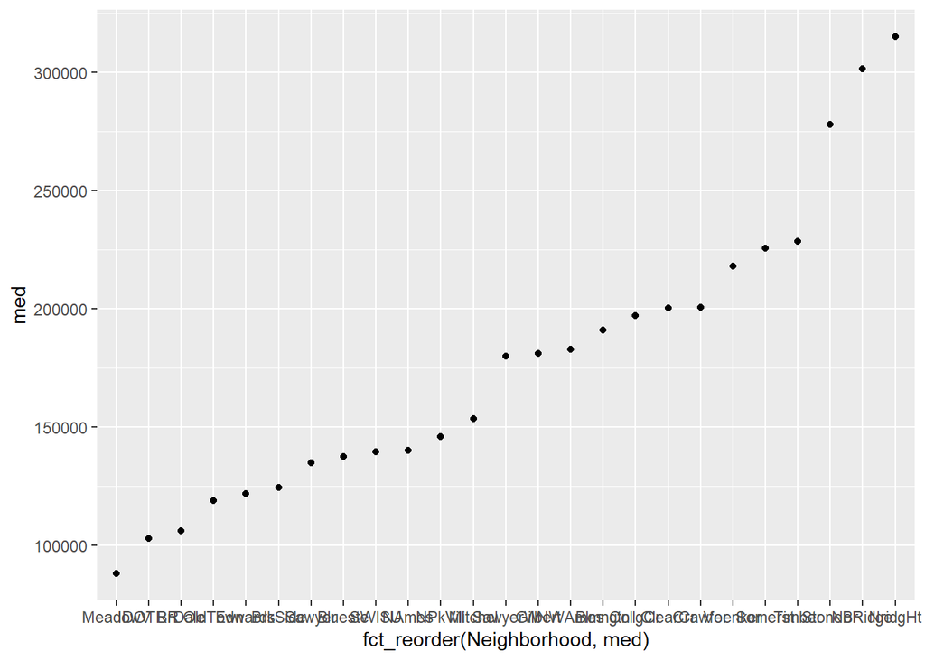

```r
train %>% group_by(Neighborhood) %>%
  summarize(
    med = median(SalePrice)
  ) %>%
  arrange(med) %>%
  ggplot(aes(fct_reorder(Neighborhood, med), med)) +
  geom_point()
```

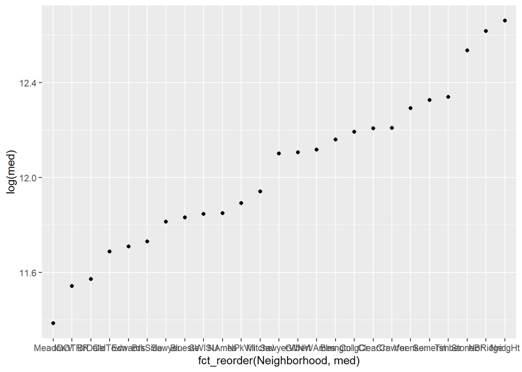

```r
train %>% group_by(Neighborhood) %>%
  summarize(
    med = median(SalePrice)
  ) %>%
  arrange(med) %>%
  ggplot(aes(fct_reorder(Neighborhood, med), log(med))) +
  geom_point()
```

```r
train <- train %>% left_join(
  train %>% group_by(Neighborhood) %>%
    summarize(
      Med = median(SalePrice)
    ) %>%
    ungroup() %>%
    mutate(
      NbhdType = case_when(
        Med < 125000 ~ "RealLow",
        Med < 175000 ~ "Low",
        Med < 250000 ~ "Mid",
        Med > 250000 ~ "High",
        .default = "Unknown"
      ),
      NbhdType2 = case_when(
        Med < 175000 ~ "Low",
        Med < 250000 ~ "Mid",
        Med > 250000 ~ "High",
        .default = "Unknown"
      )
    ),

  by = "Neighborhood"
)
```

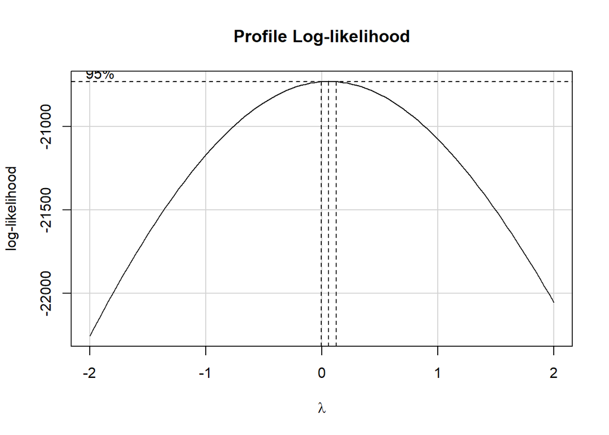

```r
lm.qual <- lm(SalePrice ~ OverallQual, train)
boxCox(lm.qual)
```

```r
lm.qual <- lm(log(SalePrice) ~ OverallQual, train)
lm.qual %>% summary()
```

```
##
## Call:
## lm(formula = log(SalePrice) ~ OverallQual, data = train)
##
## Residuals:
##      Min       1Q   Median       3Q      Max
## -1.06831 -0.12974  0.01309  0.13332  0.92438
##
## Coefficients:
##             Estimate Std. Error t value Pr(>|t|)
## (Intercept) 10.58444    0.02727  388.18   <2e-16 ***
## OverallQual  0.23603    0.00436   54.14   <2e-16 ***
## ---
## Signif. codes:  0 '***' 0.001 '**' 0.01 '*' 0.05 '.' 0.1 ' ' 1
##
## Residual standard error: 0.2303 on 1458 degrees of freedom
## Multiple R-squared:  0.6678, Adjusted R-squared:  0.6676
## F-statistic:  2931 on 1 and 1458 DF,  p-value: < 2.2e-16
```

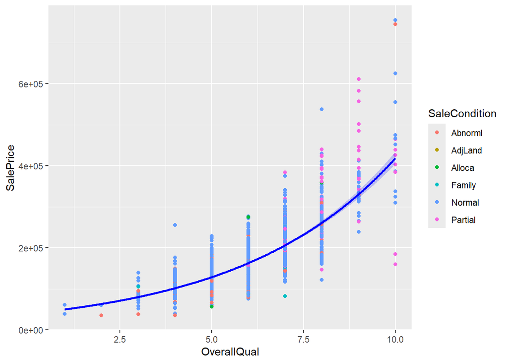

```r
ggplot(train, aes(OverallQual, SalePrice, color = SaleCondition)) +
  geom_point() +
  geom_confidence(lm.qual, exp)
```

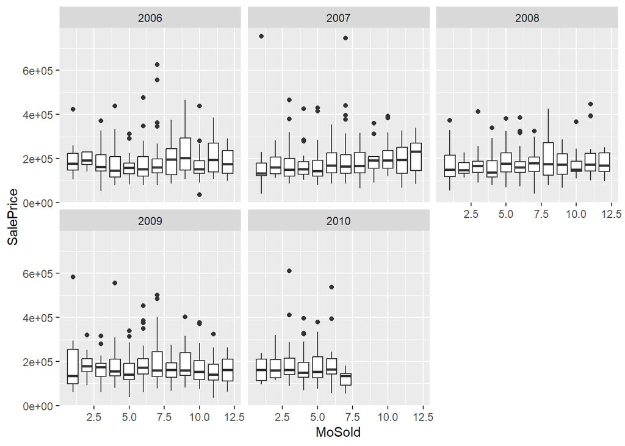

```r
ggplot(train, aes(MoSold, SalePrice)) +
  #geom_point() +
  geom_boxplot(aes(group = as.factor(MoSold))) +
  facet_wrap(~YrSold)
```